# Progetto Laboratorio di Statistica

Carmela Pia Senatore

2023-05-15

# 1. Presentazione dei dati

La prima analisi effettuata riguarda la qualità dei dati. La presenza di valori mancanti o valori anomali può notevolmente influire sull’analisi. Con la funzione **statsNA** si verifica la presenza di valori mancanti.

```r
data('auscafe')
aus.ts <- window(auscafe, start = 1983, end = c(2016, 12))
library(imputeTS)
statsNA(aus.ts)
```

```
## [1] "Length of time series:"
## [1] 408
## [1] "-------------------------"
## [1] "Number of Missing Values:"
## [1] 0
## [1] "-------------------------"
## [1] "Percentage of Missing Values:"
## [1] "0%"
## [1] "-------------------------"
## [1] "Number of Gaps:"
## [1] 0
## [1] "-------------------------"
## [1] "Average Gap Size:"
## [1] 0
## [1] "-------------------------"
## [1] "No NAs in the time series."
## [1] "-------------------------"
```

```
## [1] "There are no NAs in the time series"
```

La serie non presenta missing values. Per il riconoscimento dei valori anomali la rappresentazione grafica della serie potrebbe essere d’aiuto.

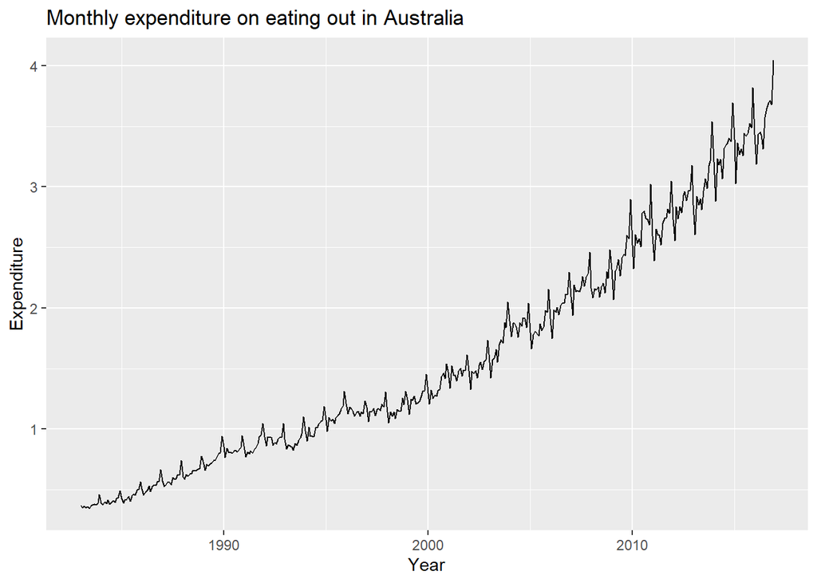

```r
autoplot(aus.ts) + ggtitle("Monthly expenditure on eating out in Australia") +
xlab("Year") +ylab("Expenditure")
```

Come da evidenza grafica, non sembrano esserci valori anomali.

# 2. Analisi descrittiva della serie storica

L’analisi descrittiva della serie storica ha come obiettivo principale la determinazione delle principali componenti: trend, stagionalità e ciclicità, oltre che l’individuazione di irregolarità.

## 2.1 Trend, Stagionalità e ciclicità

Come è possibile notare dal precedente autoplot() la serie storica presenta:

- un forte trend prettamente crescente, il livello medio di spese per mangiare fuori tende a crescere nel tempo;
- una componente di stagionalità che deve essere analizzata nello specifico;
- non presenta ciclicità;
- Si nota come è presente un incremento di variabilità nel tempo; inizialmente le oscillazioni sono molto contenute poi con il passare del tempo incrementano di variabilità.

Il grafico per il season plot riporta in basso i mesi per comprendere come la serie storica si comporta mensilmente per tutti gli anni osservati , riportati sulla colonna.

Gennaio costantemente per tutti gli anni ha un decremento di spese. Allo stesso modo consegue un decremento a febbraio, un incremento a marzo, decremento a giugno e incremento a luglio. In particolar modo il mese in cui l’incremento risulta essere maggiore è Dicembre. Questo comportamento nello stesso mese di ogni anno è espressione di stagionalità.

A febbraio il decremento potrebbe essere associato alla fine dell’estate e ritorno alla routine, oltre ad essere il mese più caldo dell’anno.

Presumibilmente la stagionalità e gli incrementi a luglio e dicembre sono dovuti a particolari situazioni in Australia. In Australia, luglio e dicembre sono mesi di vacanza molto popolari. Luglio coincide con le vacanze invernali delle scuole, mentre dicembre è il periodo delle vacanze estive. Inoltre, in Australia, luglio è anche il mese in cui si tiene il Festival della Gastronomia di Melbourne, un grande evento culinario che attira molti turisti e amanti del cibo. Questo può contribuire all’incremento di pranzi e cene. D’altra parte, dicembre è il mese delle festività natalizie, e molte persone festeggiano spesso mangiando fuori o cenando in ristoranti. In ogni caso, la componente di stagionalità è netta.

E’ possibile anche analizzare la componente di trend, focalizzando l’attenzione sul lato: il valore iniziale di spese in pranzi e cene fuori parte da 0,33 bilioni di dollari nel 1982 e si completa nel 2016 con oltre 4 bilioni. Il livello medio è sempre aumentato nel tempo esprimendo un trend crescente.

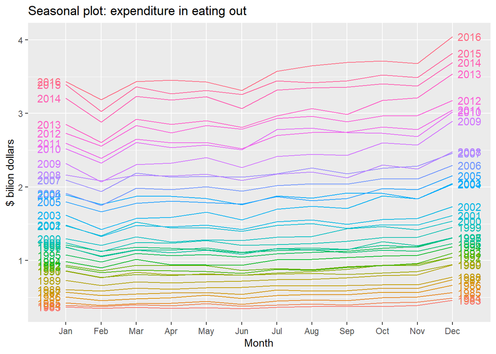

```r
ggseasonplot(aus.ts, year.labels=TRUE, year.labels.left=TRUE) +
ylab("$ bilion dollars") + ggtitle("Seasonal plot: expenditure in eating out")
```

La verifica della stagionalità può essere anche svolta attraverso l’analisi del seasonal subseries plot. Il seasonal subseries plot comprende dei minigrafici non più contenenti punto per punto per ogni anno, piuttosto dati relativi a interi mesi per ogni anno. La differenza delle medie di febbraio e dicembre è notevole, considerando che l’unità di misura è bilioni di dollari. La crescita verso l’alto per ciascun mese conferma la presenza di trend positivo e crescente.

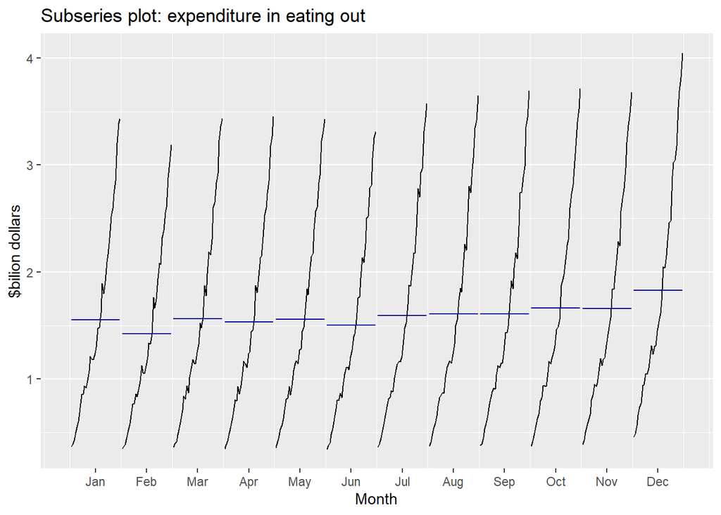

```r
ggsubseriesplot(aus.ts, year.labels=TRUE, year.labels.left=TRUE) +
ylab("$bilion dollars") + xlab("Month") +
ggtitle("Subseries plot: expenditure in eating out")
```

La serie storica analizzata non è stazionaria, in quanto le sue proprietà statistiche, influenzate da Trend e Stagionalità, dipendono dal tempo in cui la serie viene osservata.

## 2.2 ACF:

Il correlogramma mostra le autocorrelazioni della serie storica in funzione del ritardo di riferimento. Il valore di autocorrelazione più alto lo si osserva al ritardo uno e poi tende lentamente verso zero. I picchi tendono a ripetersi nel dodicesimo mese. Nelle serie white noise ogni correlazione si presenta prossima allo zero. Nel caso specifico la serie non è white noise in quanto tutti i picchi sono al di fuori delle bande di confidenza, individuate dalle linee blu tratteggiate indicanti le correlazioni come significativamente diverse da zero, la presenza di dati stagionali comporta autocorrelazioni più grandi per i ritardi stagionali. Il correlogramma, inoltre, presenta il tipico modello delle serie storiche caratterizzate da una componente di trend: le autocorrelazioni hanno valori positivi che diminuiscono lentamente all’aumentare del ritardo.

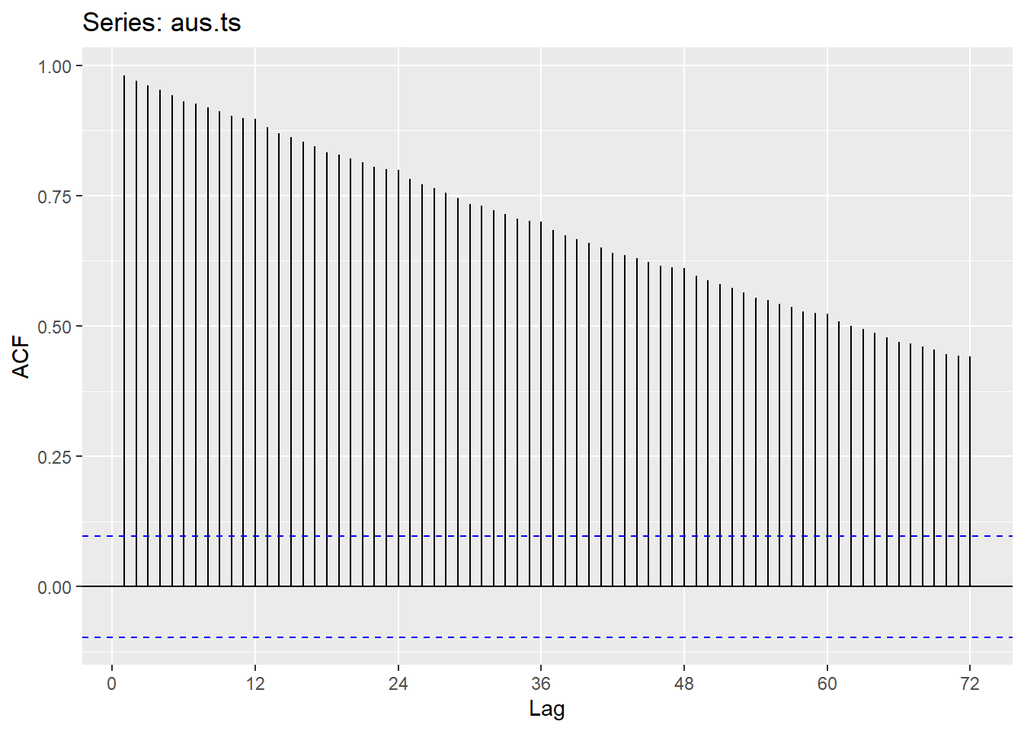

```r
ggAcf(aus.ts, lag.max = 72) + ggtitle("Series: aus.ts")
```

# 3. Modelli di previsione Benchmark

Un metodo di previsione deve tener conto dei fattori dominanti della serie, nel caso particolare Trend e Stagionalità.

In questa sede verranno confrontate le prestazioni di quattro semplici modelli di previsione:

```
1.Average Method.

2.Naive Method.

3.Seasonal Naive Method.

4.Drift Method.
```

Per misurare la Bontà di Adattamento/Previsione verranno calcolati i seguenti parametri di errore:

- **errore medio assoluto** (mean absolute error: MAE): media aritmetica degli errori presi in valore assoluto;
- **radice errore quadratico medio** (rout mean squared error: RMSE): radice quadrata della media aritmetica dei quadrati degli errori;
- **errore medio assoluto percentuale** (mean absolute percentage error: MAPE): media aritmetica degli errori relativi, presi in valore assoluto e moltiplicati per 100. In realtà non si tratta di un indice simmetrico in quanto viene dato un peso maggiore agli errori negativi rispetto agli errori positivi, per questo viene considerato un indice corretto noto come *symmetric mean absolute percentage error*, **SMAPE**.

Per verificare e comprendere i modelli di previsione, viene effettuata una divisione in **Training set e Test set.** Per far si che poi successivamente sia possibile confrontare i risultati con i modelli implementati per serie multivariate, gli archi temporali di train e split saranno i seguenti: Il traning test conterrà le osservazioni dal 1983 fino al 1989, mentre il test set conterrà le osservazioni dal 1990 al 1991.

```r
aus.ts<-window(aus.ts, start=c(1983, 1), end= c(1991,12))
aus.ts_train <- window(aus.ts, start=c(1983, 1), end=c(1989, 12))
aus.ts_test <- window (aus.ts, start = c(1990,1), end= c(1991,12))
```

- il Drift metod , ad esempio, riesce a catturare il trend, ma non tiene conto della stagionalità;
- il Seasonal naive ,invece, è in grado di catturare la componente di stagionalità ma non riesce a cogliere l’andamento del trend;
- Il naive individua il livello di andamento della serie;
- l’Average method non coglie nè il trend e nè la stagionalità.

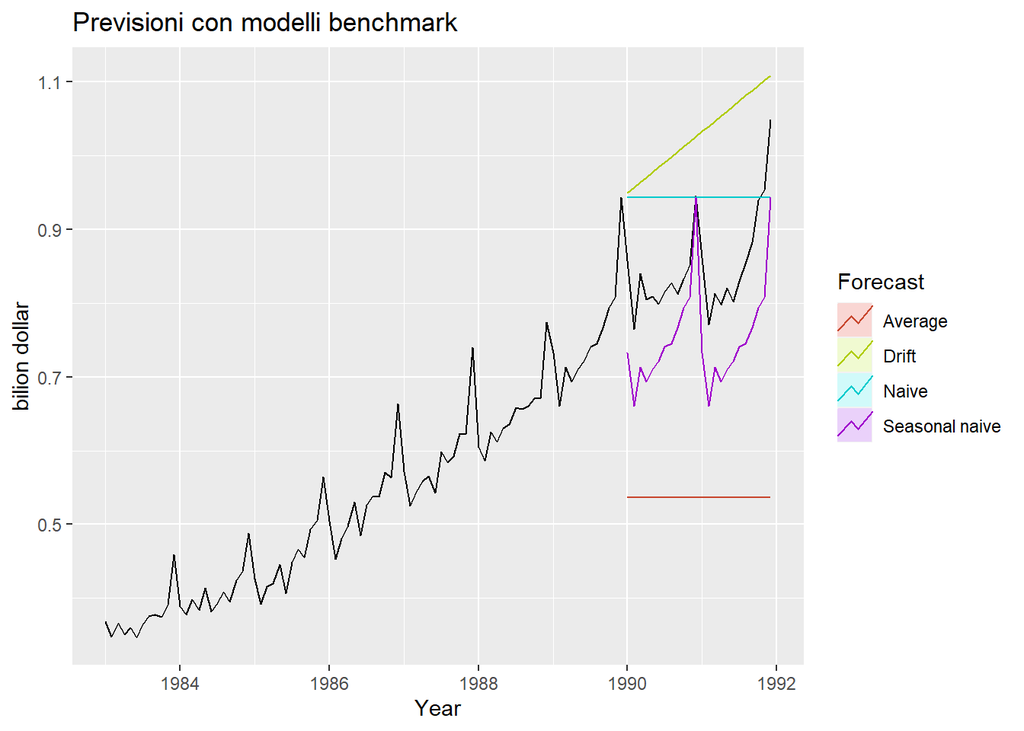

```r
m <- meanf(aus.ts_train, 24)
n <- naive(aus.ts_train, 24)
s <- snaive(aus.ts_train, 24)
r <- rwf(aus.ts_train, 24, drift = TRUE)

autoplot(aus.ts) +
autolayer(m,
series="Average", PI=FALSE) +
autolayer(n,
series="Naive", PI=FALSE) +
autolayer(s,
series="Seasonal naive", PI=FALSE) +
autolayer(r,
series="Drift", PI=FALSE) +
ggtitle("Previsioni con modelli benchmark") +
xlab("Year") + ylab("bilion dollar") +
guides(colour=guide_legend(title="Forecast"))
```

**Residual Diagnostics**

I residui rappresentano l’errore di previsione del modello statistico utilizzato per prevedere i valori di una serie storica al tempo t. Essi sono calcolati come la differenza tra il valore osservato al tempo t e il valore stimato dal modello al tempo t.

Nel contesto delle serie storiche, l’analisi dei residui è particolarmente importante perché permette di valutare l’accuratezza delle previsioni e la bontà del modello utilizzato. In particolare, l’analisi dei residui consente di:

- 1. Verificare l’ipotesi di stazionarietà della serie storica: se i residui sono casuali e non presentano alcun tipo di pattern o tendenza, ciò indica che la serie è stazionaria.
- 2. Identificare eventuali pattern o tendenze nei residui: se i residui mostrano pattern o tendenze, ciò suggerisce che il modello utilizzato non tiene conto di tutte le variazioni presenti nella serie storica e che pertanto è necessario introdurre ulteriori variabili esplicative o considerare modelli più complessi.
- 3. Valutare l’effetto di eventuali outlier o dati anomali: se i residui presentano valori molto elevati o molto bassi, ciò può indicare la presenza di dati anomali o outlier nella serie storica, che potrebbero influenzare in modo significativo le previsioni del modello.

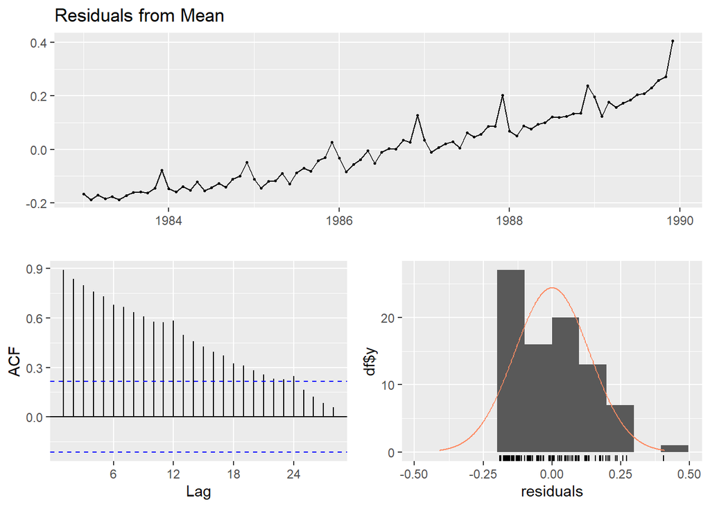

```
##
##  Ljung-Box test
##
## data:  Residuals from Mean
## Q* = 642.2, df = 17, p-value < 2.2e-16
##
## Model df: 0.   Total lags used: 17
```

```r
par(mfrow=c(2,2))
checkresiduals(m)
```

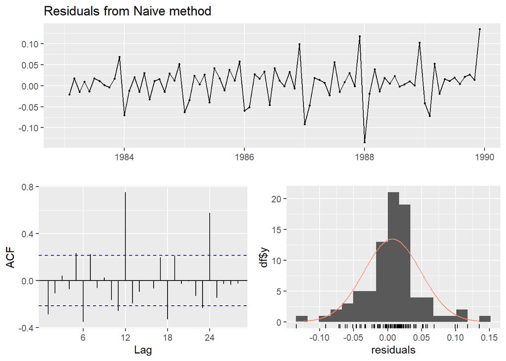

```
##
##  Ljung-Box test
##
## data:  Residuals from Naive method
## Q* = 105.1, df = 17, p-value = 9.992e-15
##
## Model df: 0.   Total lags used: 17
```

```r
checkresiduals(n)
```

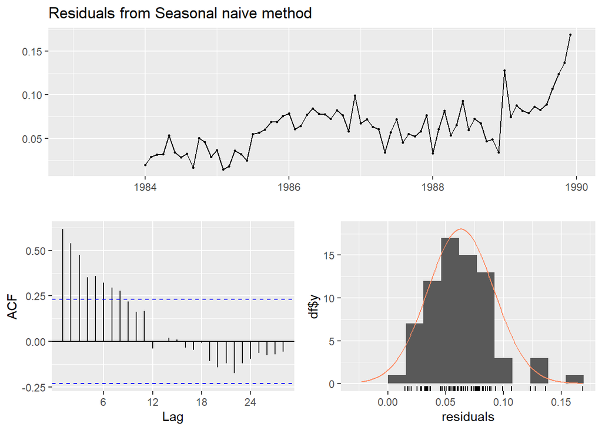

```
##
##  Ljung-Box test
##
## data:  Residuals from Seasonal naive method
## Q* = 119.36, df = 17, p-value < 2.2e-16
##
## Model df: 0.   Total lags used: 17
```

```r
checkresiduals(s)
```

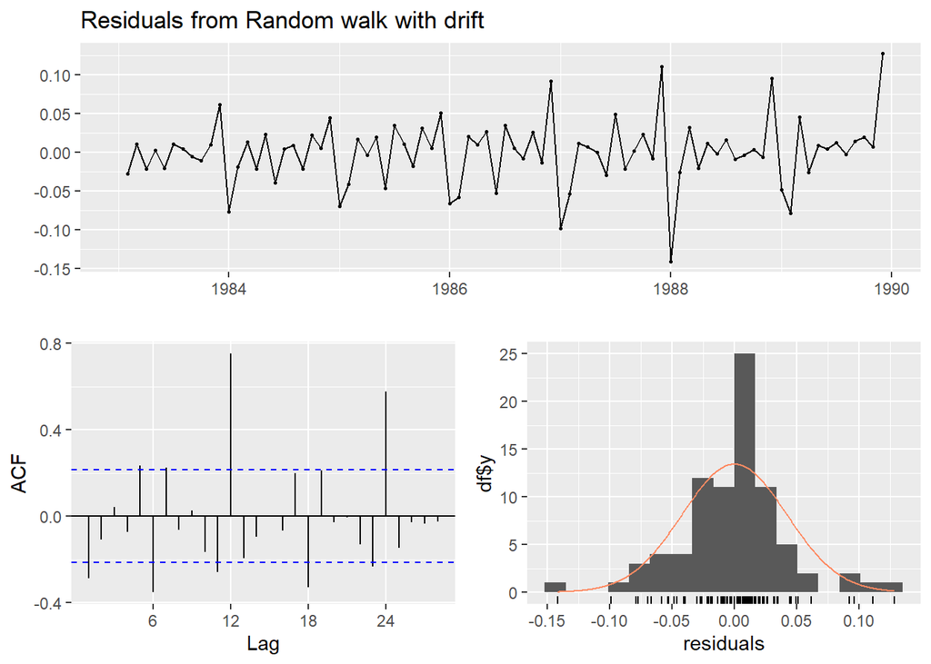

```
##
##  Ljung-Box test
##
## data:  Residuals from Random walk with drift
## Q* = 105.1, df = 17, p-value = 9.992e-15
##
## Model df: 0.   Total lags used: 17
```

```r
checkresiduals(r, drift = TRUE)
```

Ovviamente, nessuno dei residui analizzati mostra un’andamento White noise.

**Valutazione dell’accuratezza**

Dalla valutazione del fitting sul training set emerge che fra i metodi il migliore è il Random Walk con Drift perchè ritorna un valore di fit più basso.

```r
accuracy.t<- rbind(
average = forecast::accuracy(m, aus.ts_test)[1,c(2,3,4,5)],
naive = forecast::accuracy(n, aus.ts_test)[1,c(2,3,4,5)],
seasonal.naive = forecast::accuracy(s, aus.ts_test)[1,c(2,3,4,5)],
rwd = forecast::accuracy(r, aus.ts_test)[1,c(2,3,4,5)])
rownames(accuracy.t) <- c("Average","Naive","Seasonal Naive", "Random Walk con Drift")
accuracy.t
```

```
##                             RMSE        MAE        MPE      MAPE
## Average               0.13556635 0.11447840 -6.4051407 22.563044
## Naive                 0.04242624 0.03066386  0.8589356  5.691446
## Seasonal Naive        0.06925295 0.06315139 10.9307316 10.930732
## Random Walk con Drift 0.04185860 0.02929656 -0.5076156  5.484218
```

Valutando l’accuratezza previsiva sul test set si conferma l’impressione grafica: il miglior modello previsivo tra i modelli benchmark presi in esame è il Seasonal Naive in quanto presenta i valori più bassi per RMSE, MAE e MAPE. Quel che sorprende maggiormente , focalizzando l’attenzione sull output della tabella e il plot precedentemente analizzato, l’accuratezza previsiva del metodo Naive e del Seasonal Naive è molto simile.

```r
accuracy.te <- rbind(
average = forecast::accuracy(m, aus.ts_test)[2,c(2,3,4,5)],
naive = forecast::accuracy(n, aus.ts_test)[2,c(2,3,4,5)],
seasonal.naive = forecast::accuracy(s, aus.ts_test)[2,c(2,3,4,5)],
rwd = forecast::accuracy(r, aus.ts_test)[2,c(2,3,4,5)])
rownames(accuracy.te) <- c("Average","Naive","Seasonal Naive", "Random Walk con Drift")
accuracy.te
```

```
##                            RMSE        MAE       MPE     MAPE
## Average               0.3175455 0.31095714  36.37360 36.37360
## Naive                 0.1151982 0.10552500 -11.86388 12.82675
## Seasonal Naive        0.1005573 0.09465833  11.20340 11.20340
## Random Walk con Drift 0.1901035 0.18201084 -21.90710 21.90710
```

# 4. Decomposizione

La decomposizione delle serie storiche serve a scomporre una serie temporale complessa in componenti più semplici e interpretabili. Questo processo di scomposizione aiuta a comprendere meglio i diversi fattori che influenzano i dati nel tempo e il grado di incidenza di ciascuna componente rispetto all’intero fenomeno nel tempo osservato. Esistono due tipi di decomposizioni:

```
* **utilizzando il modello additivo**, solitamente nei casi in cui l'ampiezza dell'oscillazione stagionale non varia col livello della serie;
* **utilizzando il modello moltiplicativo**, indicato per i casi in cui la fluttuazione stagionale aumenta (o diminuisce) proporzionalmente con l'aumento (diminuzione) del livello della serie.
```

Poichè la serie analizzata mostra variazioni stagionali che cambiano proporzionalmente al livello della serie, si è ritenuto migliore l’applicazione moltiplicativa.

## 4.1 Decomposizione moltiplicativa classica

La serie storica originale è ritenuta prodotto delle tre componenti *yt = St x Tt x Rt*, dove:

- yt è il dato riferito al periodo t;
- Tt è la componente trend-ciclo al periodo t;
- St è la componente stagionale al periodo t;
- Rt è la componente irregolare (casuale) residua al periodo t.

La decomposizione classica individua un trend crescente approssimabilmente lineare ma rilevato come leggermente curvo, una componente stagionale che è costante nel tempo il quale picco massimo si raggiunge nel mese di dicembre e il valore minimo si osserva generalmente nel mese di febbraio. Individua valori anomali nei residui per gennaio di quasi tutti gli anni. Tuttavia, oltre che la stima non è disponibile per le prime e ultime osservazioni, l’approccio classico non è esente da problemi:

1. *Smussamento eccessivo del trend*: Nell’approccio classico, il trend stimato tende a ridurre troppo l’ampiezza delle fluttuazioni al rialzo e al ribasso nei dati. Ciò può portare a una perdita di informazioni preziose sul comportamento reale della serie temporale.
2. *Mancanza di adattabilità alla stagionalità mutevole*: L’approccio classico considera la componente stagionale come ripetitiva di anno in anno in modo costante. Di conseguenza, non tiene conto dei possibili cambiamenti stagionali che potrebbero verificarsi nel tempo, come variazioni nella durata o nella forma dei pattern stagionali.
3. *Sensibilità agli outlier*: I metodi di decomposizione moltiplicativa classici sono sensibili ai valori insoliti o agli outlier presenti nella serie temporale. Questi valori estremi possono influenzare in modo significativo le stime delle componenti trend e stagionalità, compromettendo la precisione complessiva della decomposizione.

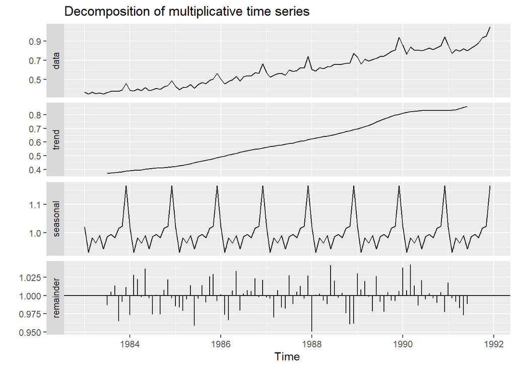

```r
multiplicative <- decompose(aus.ts,type = "multiplicative")
autoplot(multiplicative)
```

## 4.2 Decomposizione X11

Nella decomposzione X11 i dati sono stati trasformati con il logaritmo il che significa che è stata effettivamente applicata una decomposizione moltiplicativa.

```r
x11.fit <- seas(aus.ts, transform.function="auto", x11="")
summary(x11.fit)$transform.function #è stata applicata la decomposizione moltiplicativa
```

```
## [1] "log"
```

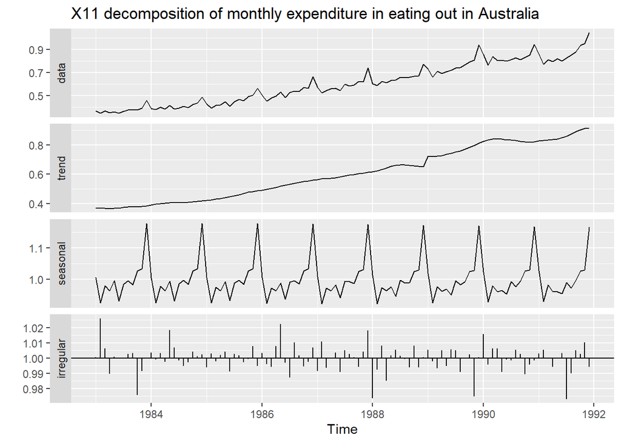

```r
autoplot(x11.fit) + ggtitle("X11 decomposition of monthly expenditure in eating out in Australia")
```

## 4.3 Decomposizione X13 SEATS

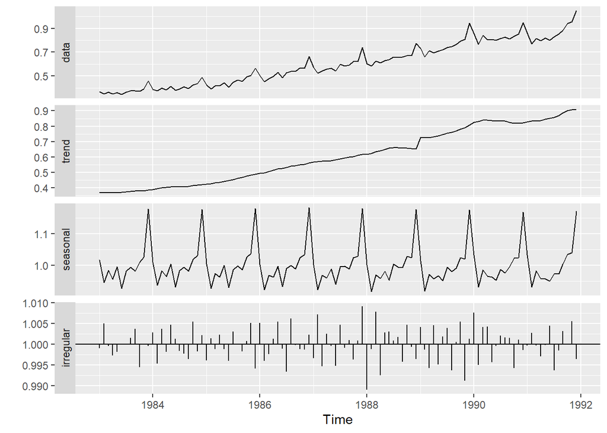

```r
x13.seats = seas(aus.ts)
autoplot(x13.seats)
```

## 4.4 Decomposizione STL

È stato dapprima applicata la trasformata di Box-Cox e poi la decomposizione additiva. La decomposizione STL permette di comprendere quale componente presenta un impatto maggiore. Sulla base della forza rappresentata, il trend impatta maggiormente sulla serie storica, a seguire la stagionalità e per nulla influente i residui. Se fossero presenti valori anomali questi verrebbero cattuarti dai residui che avrebbero un impatto maggiore.

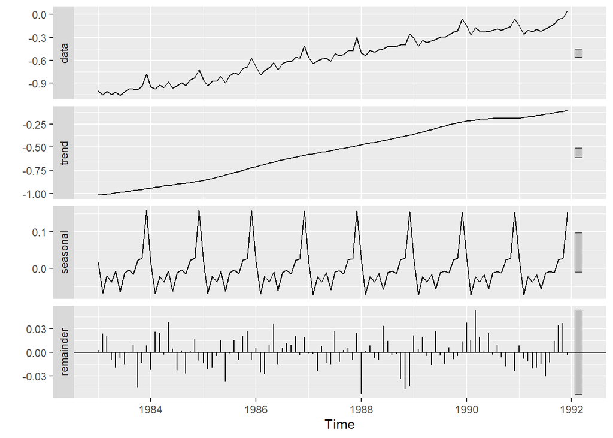

```r
aus_trans<-BoxCox(aus.ts, lambda = 0)
stl.s <- stl(aus_trans, s.window=12, robust=TRUE)
autoplot(stl.s)
```

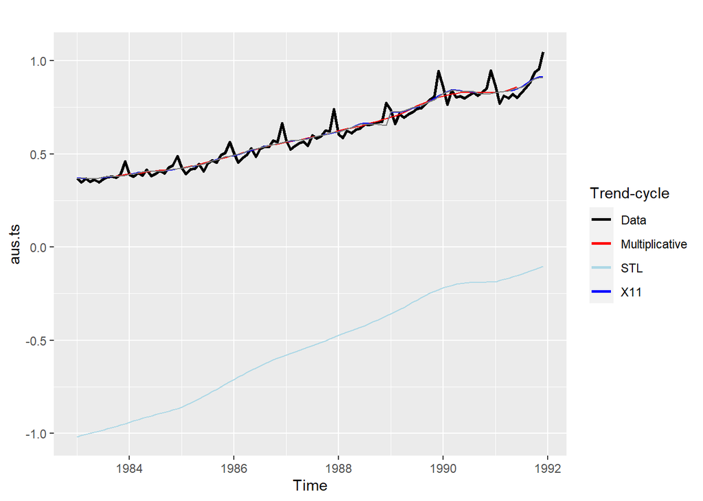

```r
autoplot(aus.ts, series="Data", size=1) +
autolayer(trendcycle(multiplicative), series="Multiplicative") +
autolayer(trendcycle(x11.fit), series="X11") +
autolayer(trendcycle(x13.seats), series="X13-SEATS") +
autolayer(trendcycle(stl.s), series="STL")+
guides(colour = guide_legend(title = "Trend-cycle")) +
scale_colour_manual(values=c("Data"="black","Multiplicative"="red", "X11"="blue","X13-SEAT
S"="green", "STL"="light blue"))
```

### Conclusioni sulle decomposizioni

Nei grafici di decomposizione X11, la combinazione delle componenti trend, stagionalità e residua offre una rappresentazione complessiva più dettagliata della serie temporale. I grafici X11 tendono a mostrare una maggiore variabilità e dettaglio rispetto ai grafici della decomposizione classica, che possono essere più lisci e meno sensibili alle fluttuazioni a breve termine. La decomposizione X13 di differenzia di poco dalla X11 in termini di residui.

# 5. Analisi dei modelli di regressione

## 5.1 Modello con trend e stagionalità.

Poichè la serie storica risulta essere fortemente contraddistinta da trend e stagionalità è possibile stimare un modello in cui gli unici due regressori sono proprio le due componenti. La possibile applicazione vale esplicitamente e espressamente per le serie storiche con andamento prettamente crescente o decrescente, mentre non rimane valida per serie che mostrano cambi di direzione.

```r
mod1 <- tslm(aus.ts_train ~ trend )
summary(mod1)
```

```
##
## Call:
## tslm(formula = aus.ts_train ~ trend)
##
## Residuals:
##       Min        1Q    Median        3Q       Max
## -0.062640 -0.025694 -0.006349  0.014367  0.184886
##
## Coefficients:
##              Estimate Std. Error t value Pr(>|t|)
## (Intercept) 0.3092318  0.0089468   34.56   <2e-16 ***
## trend       0.0053403  0.0001828   29.21   <2e-16 ***
## ---
## Signif. codes:  0 '***' 0.001 '**' 0.01 '*' 0.05 '.' 0.1 ' ' 1
##
## Residual standard error: 0.04063 on 82 degrees of freedom
## Multiple R-squared:  0.9123, Adjusted R-squared:  0.9112
## F-statistic:   853 on 1 and 82 DF,  p-value: < 2.2e-16
```

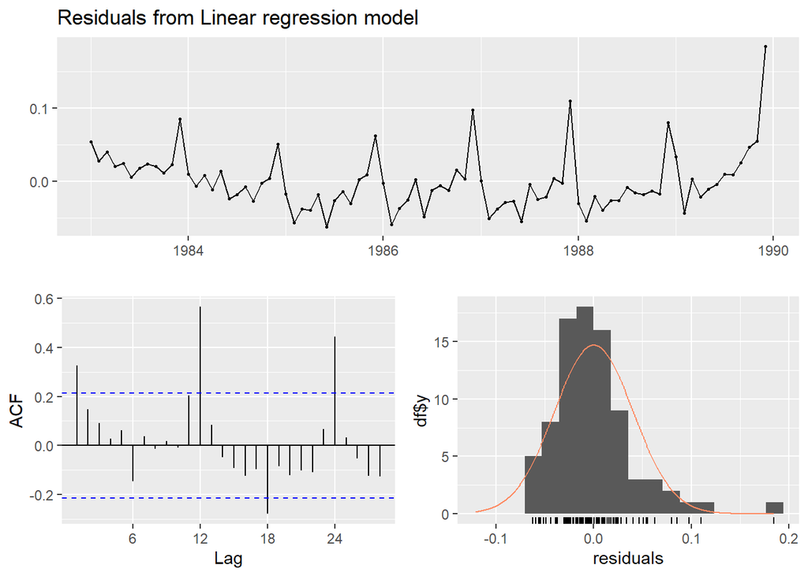

```
##
##  Breusch-Godfrey test for serial correlation of order up to 17
##
## data:  Residuals from Linear regression model
## LM test = 60.328, df = 17, p-value = 9.276e-07
```

```r
checkresiduals(mod1)
```

Per questo motivo, il secondo modello considerato contiene sia trend che stagionalità, con l’obiettivo di creare un modello in grado di catturare entrambe le componenti. Le dummy individuate fanno riferimento ai diversi mesi dell’anno: l’informazione contenuta in yt fa riferimento all’osservazione appartenente al primo mese dell’anno. Dal summary del modello appena implementato si deduce che:

Valutando l’Adjusted R-squared, rappresentante della quota parte di variabilità della forecast variabile catturata dal modello, assume un valore molto alto pari a 0.96. Ad ogni modo l’indice R^2 non è un indice che ha rilievo nella valutazione della perforamance previsiva del modello.

```r
mod2 <- tslm(aus.ts_train ~ trend + season)
summary(mod2)
```

```
##
## Call:
## tslm(formula = aus.ts_train ~ trend + season)
##
## Residuals:
##       Min        1Q    Median        3Q       Max
## -0.048061 -0.016814 -0.004959  0.015934  0.093155
##
## Coefficients:
##               Estimate Std. Error t value Pr(>|t|)
## (Intercept)  0.3205609  0.0107962  29.692  < 2e-16 ***
## trend        0.0052231  0.0001186  44.025  < 2e-16 ***
## season2     -0.0416374  0.0139496  -2.985  0.00389 **
## season3     -0.0182461  0.0139511  -1.308  0.19514
## season4     -0.0272978  0.0139537  -1.956  0.05436 .
## season5     -0.0122637  0.0139572  -0.879  0.38255
## season6     -0.0371153  0.0139617  -2.658  0.00970 **
## season7     -0.0121670  0.0139673  -0.871  0.38663
## season8     -0.0110900  0.0139738  -0.794  0.43006
## season9     -0.0149560  0.0139814  -1.070  0.28837
## season10     0.0034353  0.0139899   0.246  0.80674
## season11     0.0049122  0.0139995   0.351  0.72671
## season12     0.0902463  0.0140100   6.442 1.22e-08 ***
## ---
## Signif. codes:  0 '***' 0.001 '**' 0.01 '*' 0.05 '.' 0.1 ' ' 1
##
## Residual standard error: 0.0261 on 71 degrees of freedom
## Multiple R-squared:  0.9687, Adjusted R-squared:  0.9634
## F-statistic:   183 on 12 and 71 DF,  p-value: < 2.2e-16
```

### Confronto grafico tra spesa osservata e spesa prevista

Il modello stimato cattura gran parte della stagionalità e trend, tuttavia sovrastima i dati per l’arco temporale che va dal 1984 al 1986 e sottostima dal 1988 in poi.

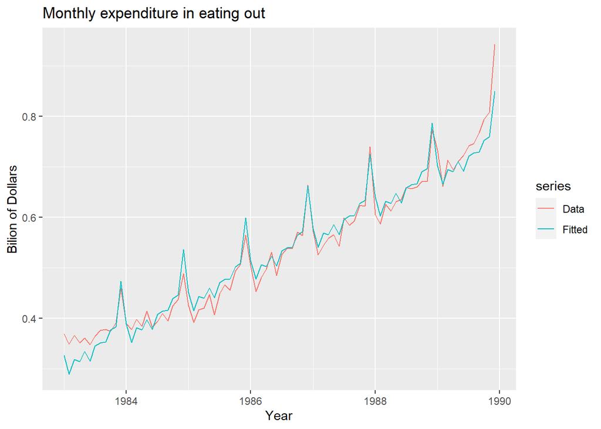

```r
autoplot(aus.ts_train, series="Data") +
autolayer(fitted(mod2), series="Fitted") +
xlab("Year") + ylab("Bilion of Dollars") +
ggtitle("Monthly expenditure in eating out")
```

Per la verifica dell’adattamento del modello ai dati è possibile analizzare , tramite un confronto grafico, i valori reali e quelli stimati. I punti sono abbastanza vicini ai reali per certi versi, ma molto distanti per altri. I punti sono stati colorati per ogni mese per comprenderne l’effetto, tuttavia, l’elevata numerosità non rende chiara la distinzione.

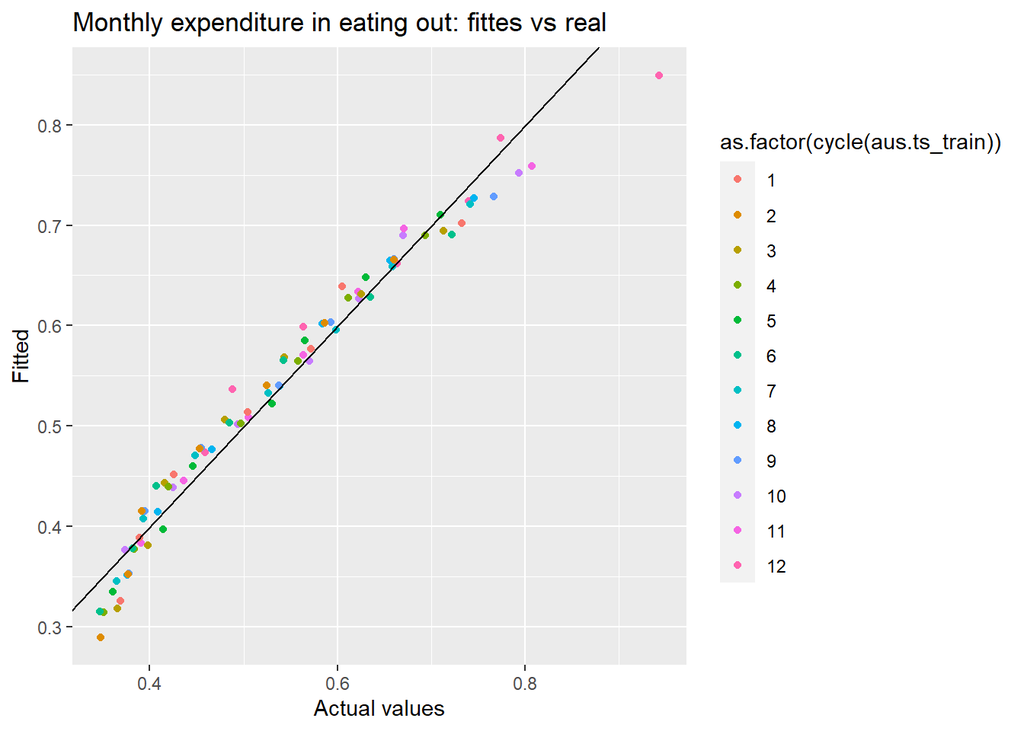

```r
cbind(Data=aus.ts_train, Fitted=fitted(mod2)) %>%
as.data.frame() %>%
ggplot(aes(x = Data, y = Fitted,
colour = as.factor(cycle(aus.ts_train)))) +
geom_point() +
ylab("Fitted") + xlab("Actual values") +
ggtitle("Monthly expenditure in eating out: fittes vs real") +
geom_abline(intercept=0, slope=1)
```

**Analisi dei residui del modello con trend e stagionalità**

Valutando il test e i grafici implementati sui residui, questi non sono White Noise. Il test implementato è quello di Breusch-Godfrey per i modelli di regressione per testare se i residui risultano essere incorrelati. Come prima, i residui non mostrano un andamento White Noise: sono correlati, hanno distribuzione diversa da quella normale e non sembrano avere una stazionarietà in media. Il modello con solo trend e stagionalità non è per nulla ottimo.

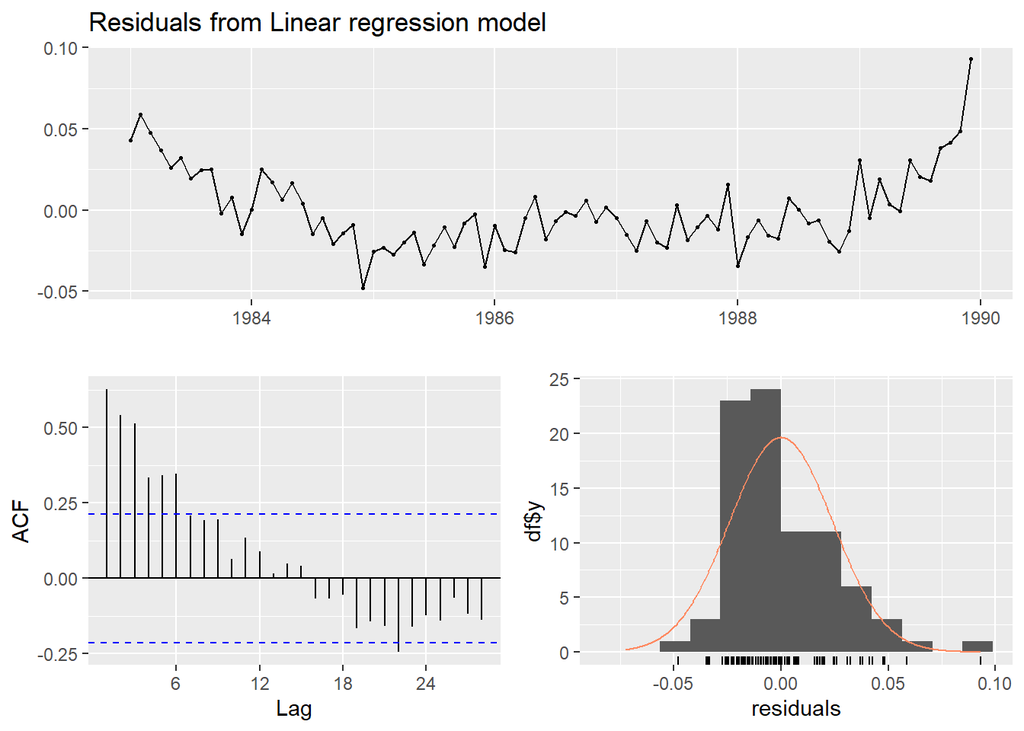

```
##
##  Breusch-Godfrey test for serial correlation of order up to 17
##
## data:  Residuals from Linear regression model
## LM test = 55.231, df = 17, p-value = 6.291e-06
```

```r
checkresiduals(mod2)
```